# TidyModels - PCA and UMAP

Karat Sidhu

2022-05-22

# TidyModels - PCA & UMAP

## Dimensionality Reduction analysis with Tidymodels

Principal Component analysis (and UMAP to a lesser extent) have been extensively used in Biological Sciences and specifically in Omics. Compared to other components of the TidyVerse, I am fairly comfortable using and running the PCA test on a set of data. However, I typically use either the base R (`prcom`) or PCA Tools[^1] because generating a series of plots using those packages is fairly straightforward[^2].

# Cocktail Recipes Dataset

The dataset used is from the Tidytuesday data, where different cocktails and the components used for their recipes is provided.  
Reducing dimensions in such a case would help in finding out which cocktail is closely related to the other in terms of their components.

# Loading packages

```r
library(tidyverse)
library(tidymodels)
library(tidytext)
```

# Loading Data

```r
boston_cocktails <-
  readr::read_csv("https://raw.githubusercontent.com/rfordatascience/tidytuesday/master/data/2020/2020-05-26/boston_cocktails.csv")
```

# Data Cleaning and Exploratory Data Analysis

Preliminary look at the data

```r
boston_cocktails
```

```
## # A tibble: 3,643 × 6
##    name            category           row_id ingredient_numb… ingredient measure
##    <chr>           <chr>               <dbl>            <dbl> <chr>      <chr>
##  1 Gauguin         Cocktail Classics       1                1 Light Rum  2 oz
##  2 Gauguin         Cocktail Classics       1                2 Passion F… 1 oz
##  3 Gauguin         Cocktail Classics       1                3 Lemon Jui… 1 oz
##  4 Gauguin         Cocktail Classics       1                4 Lime Juice 1 oz
##  5 Fort Lauderdale Cocktail Classics       2                1 Light Rum  1 1/2 …
##  6 Fort Lauderdale Cocktail Classics       2                2 Sweet Ver… 1/2 oz
##  7 Fort Lauderdale Cocktail Classics       2                3 Juice of … 1/4 oz
##  8 Fort Lauderdale Cocktail Classics       2                4 Juice of … 1/4 oz
##  9 Apple Pie       Cordials and Liqu…      3                1 Apple sch… 3 oz
## 10 Apple Pie       Cordials and Liqu…      3                2 Cinnamon … 1 oz
## # … with 3,633 more rows
```

So the PCA should be carried out for the “name” field and looking at the relation between the cocktail and the incredients, category and the measured amount of each ingredient used.

## Most Common Ingredients

```r
boston_cocktails |>
  count(ingredient, sort = TRUE)
```

```
## # A tibble: 569 × 2
##    ingredient            n
##    <chr>             <int>
##  1 Gin                 176
##  2 Fresh lemon juice   138
##  3 Simple Syrup        115
##  4 Vodka               114
##  5 Light Rum           113
##  6 Dry Vermouth        107
##  7 Fresh Lime Juice    107
##  8 Triple Sec          107
##  9 Powdered Sugar       90
## 10 Grenadine            85
## # … with 559 more rows
```

A lot of cocktails look like are using Gin, Lemon Juice, Syrup and Vodka as some of the most common ingredients.

## Column Cleaning and data conversion

The data isn’t very clean yet. Some ingredients, which are clearly the same are labelled slightly differently. So we need to clean and make the data usable for our analysis.

Some of the main changes needed in the **ingredients**:

- turn all ingredients to lowercase
- “-” needs to be chagned to ” ”
- “lemon” to “lemon Juice”
- “lime” to “lime juice”
- “grapefruit” to “grapefruit juice” (same for orange)

Some of the main changes needed in the **measure**:

- 1/2 to 0.5
- 3/4 to 0.75
- 1/4 to 0.25
- remove words like “dash”, and “oz” etc.
- Convert the entire column into a number

```r
cocktails <- boston_cocktails |>
  mutate(
    ingredient = str_to_lower(ingredient),
    ingredient = str_replace_all(ingredient, "-", " "),
    ingredient = str_remove(ingredient, " liqueur$"),
    ingredient = str_remove(ingredient, " (if desired)$"),
    ingredient = case_when(
      str_detect(ingredient, "bitters") ~ "bitters",
      str_detect(ingredient, "lemon") ~ "lemon juice",
      str_detect(ingredient, "lime") ~ "lime juice",
      str_detect(ingredient, "grapefruit") ~ "grapefruit juice",
      str_detect(ingredient, "orange") ~ "orange juice",
      TRUE ~ ingredient
    ),
    measure = case_when(
      str_detect(ingredient, "bitters") ~ str_replace(measure, "oz$", "dash"),
      TRUE ~ measure
    ),
    measure = str_replace(measure, " ?1/2", ".5"),
    measure = str_replace(measure, " ?3/4", ".75"),
    measure = str_replace(measure, " ?1/4", ".25"),
    measure_number = parse_number(measure),
    measure_number = if_else(str_detect(measure, "dash$"), # a few drops = so 0.02 oz
      measure_number / 50,
      measure_number
    )
  ) |>
  add_count(ingredient) |>
  filter(n > 15) |>
  select(-n) |>
  distinct(row_id, ingredient, .keep_all = TRUE) |>
  na.omit()
cocktails
```

```
## # A tibble: 2,542 × 7
##    name       category row_id ingredient_numb… ingredient measure measure_number
##    <chr>      <chr>     <dbl>            <dbl> <chr>      <chr>            <dbl>
##  1 Gauguin    Cocktai…      1                1 light rum  2 oz              2
##  2 Gauguin    Cocktai…      1                3 lemon jui… 1 oz              1
##  3 Gauguin    Cocktai…      1                4 lime juice 1 oz              1
##  4 Fort Laud… Cocktai…      2                1 light rum  1.5 oz            1.5
##  5 Fort Laud… Cocktai…      2                2 sweet ver… .5 oz             0.5
##  6 Fort Laud… Cocktai…      2                3 orange ju… .25 oz            0.25
##  7 Fort Laud… Cocktai…      2                4 lime juice .25 oz            0.25
##  8 Cuban Coc… Cocktai…      4                1 lime juice .5 oz             0.5
##  9 Cuban Coc… Cocktai…      4                2 powdered … .5 oz             0.5
## 10 Cuban Coc… Cocktai…      4                3 light rum  2 oz              2
## # … with 2,532 more rows
```

## New Dataframe with a “wide” format

We’re now close to beginning our analysis. However, the data is in long format and PCA prefers to get the data wider. So we’ll pivot_wide to make the analysis easier.

```r
cocktails_df <- cocktails |>
  select(-ingredient_number, -row_id, -measure) |>
  pivot_wider(names_from = ingredient, values_from = measure_number, values_fill = 0) |>
  janitor::clean_names() |>
  na.omit()

cocktails_df
```

```
## # A tibble: 937 × 42
##    name    category light_rum lemon_juice lime_juice sweet_vermouth orange_juice
##    <chr>   <chr>        <dbl>       <dbl>      <dbl>          <dbl>        <dbl>
##  1 Gauguin Cocktai…      2           1          1               0           0
##  2 Fort L… Cocktai…      1.5         0          0.25            0.5         0.25
##  3 Cuban … Cocktai…      2           0          0.5             0           0
##  4 Cool C… Cocktai…      0           0          0               0           1
##  5 John C… Whiskies      0           1          0               0           0
##  6 Cherry… Cocktai…      1.25        0          0               0           0
##  7 Casa B… Cocktai…      2           0          1.5             0           0
##  8 Caribb… Cocktai…      0.5         0          0               0           0
##  9 Amber … Cordial…      0           0.25       0               0           0
## 10 The Jo… Whiskies      0           0.5        0               0           0
## # … with 927 more rows, and 35 more variables: powdered_sugar <dbl>,
## #   dark_rum <dbl>, cranberry_juice <dbl>, pineapple_juice <dbl>,
## #   bourbon_whiskey <dbl>, simple_syrup <dbl>, cherry_flavored_brandy <dbl>,
## #   light_cream <dbl>, triple_sec <dbl>, maraschino <dbl>, amaretto <dbl>,
## #   grenadine <dbl>, apple_brandy <dbl>, brandy <dbl>, gin <dbl>,
## #   anisette <dbl>, dry_vermouth <dbl>, apricot_flavored_brandy <dbl>,
## #   bitters <dbl>, straight_rye_whiskey <dbl>, benedictine <dbl>, …
```

This will be the starting dataset used to run PCA (and UMAP)

# Principal Component Analysis

Henceforth I will be using CMDLineTips Post[^3] as a reference because I’ve never done a PCA with TidyModels before.

## Prepare the analysis

### Recipe code

```r
pca_rec <- recipe(~., data = cocktails_df) |>  # what data to use
  update_role(name, category, new_role = "id") |> # name and category are identifiers not variables
  step_normalize(all_predictors()) |> # normalize all other columns
  step_pca(all_predictors()) # pca for all other columns
```

### Prep Code

```r
pca_prep <- prep(pca_rec)

pca_prep
```

```
## Recipe
##
## Inputs:
##
##       role #variables
##         id          2
##  predictor         40
##
## Training data contained 937 data points and no missing data.
##
## Operations:
##
## Centering and scaling for light_rum, lemon_juice, lime_juice, sweet_vermo... [trained]
## PCA extraction with light_rum, lemon_juice, lime_juice, sweet_vermou... [trained]
```

The prep object now doesn’t contain any output, and we need to tidy the object to read it. List object contains the PCA “results” and components on the 2nd place under “term_info” (open it in the console to see details).

## PCA Table

```r
tidied_pca <- tidy(pca_prep, 2)

tidied_pca
```

```
## # A tibble: 1,600 × 4
##    terms             value component id
##    <chr>             <dbl> <chr>     <chr>
##  1 light_rum        0.163  PC1       pca_i2nka
##  2 lemon_juice     -0.0140 PC1       pca_i2nka
##  3 lime_juice       0.224  PC1       pca_i2nka
##  4 sweet_vermouth  -0.0661 PC1       pca_i2nka
##  5 orange_juice     0.0308 PC1       pca_i2nka
##  6 powdered_sugar  -0.476  PC1       pca_i2nka
##  7 dark_rum         0.124  PC1       pca_i2nka
##  8 cranberry_juice  0.0954 PC1       pca_i2nka
##  9 pineapple_juice  0.119  PC1       pca_i2nka
## 10 bourbon_whiskey  0.0963 PC1       pca_i2nka
## # … with 1,590 more rows
```

## PCA Plots

A lot of Principal components seen, plotting the first 4

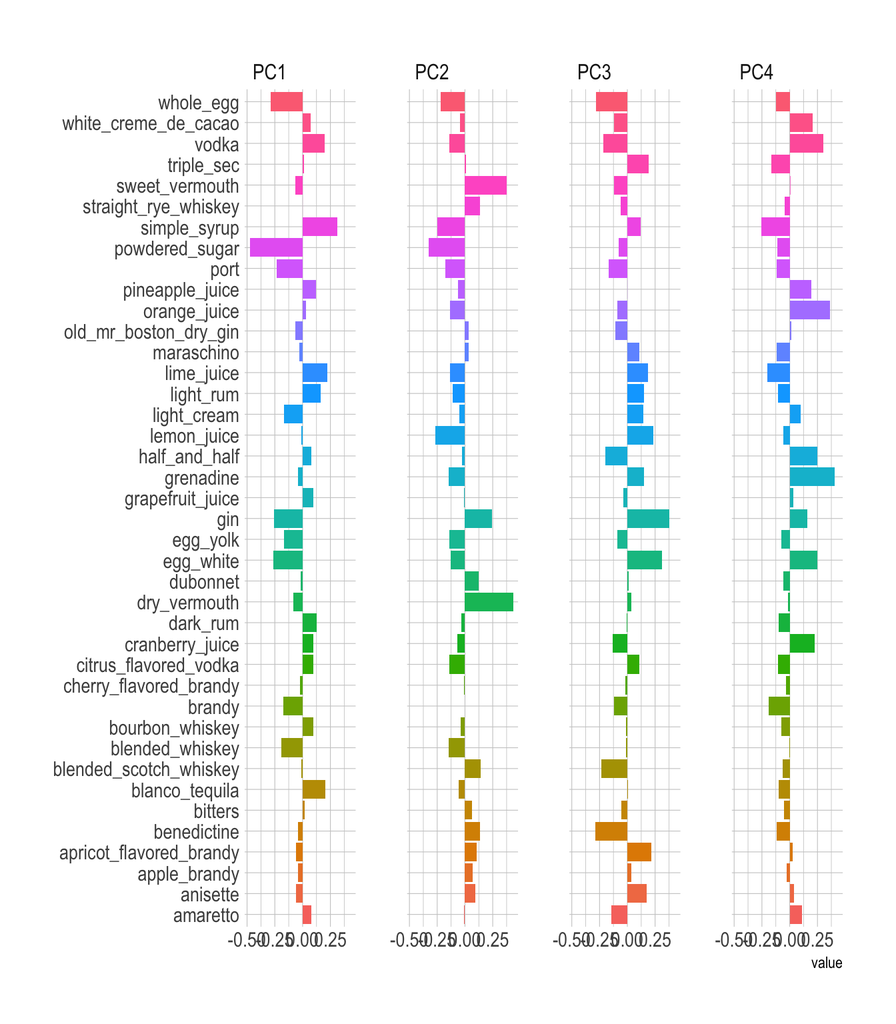

```r
tidied_pca |>
  filter(
    component == "PC1" |
      component == "PC2" |
      component == "PC3" |
      component == "PC4"
   ) |>
  mutate(component = fct_inorder(component)) |>
    ggplot(aes(value, terms, fill = terms)) +
  geom_col(show.legend = FALSE) +
  facet_wrap(~component, nrow = 1) +
  hrbrthemes::theme_ipsum() +
  labs(y = NULL)
```

Looking at the PC1, simple syrup and powdered sugar are very different from each other, therefore the cocktails must be using one or the other. They also appear to be the two biggest factors.

### PC1 and PC2 main contributors

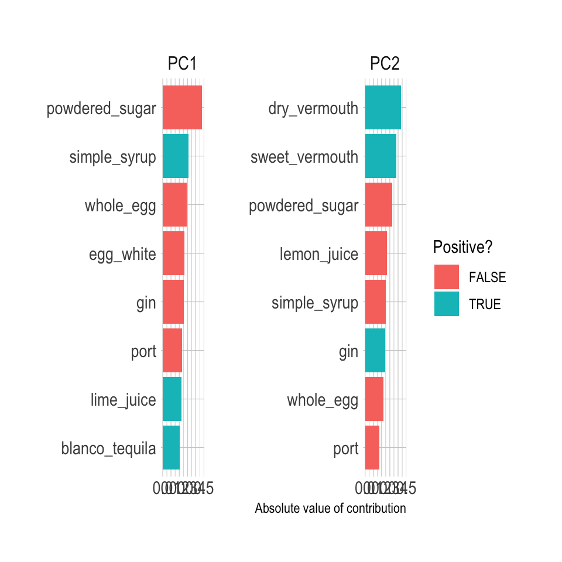

```r
tidied_pca |>
  filter(component %in% paste0("PC", 1:2)) |>
  group_by(component) |>
  top_n(8, abs(value)) |>
  ungroup() |>
  mutate(terms = reorder_within(terms, abs(value), component)) |>
  ggplot(aes(abs(value), terms, fill = value > 0)) +
  geom_col() +
  facet_wrap(~component, scales = "free_y") +
  scale_y_reordered() +
  labs(
    x = "Absolute value of contribution",
    y = NULL, fill = "Positive?"
  ) +
  hrbrthemes::theme_ipsum()
```

### PCA Plot

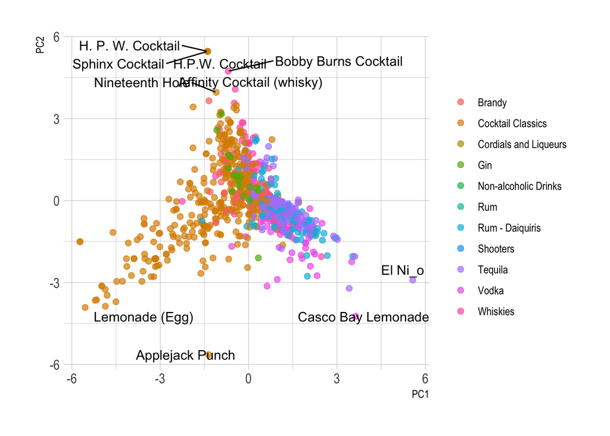

```r
juice(pca_prep) |>
  ggplot(aes(PC1, PC2, label = name)) +
  geom_point(aes(color = category), alpha = 0.7, size = 2) +
  ggrepel::geom_text_repel(check_overlap = TRUE, hjust = "inward", max.overlaps = 10) +
  labs(color = NULL) + hrbrthemes::theme_ipsum()
```

Similar kind of cocktails are clustered together, so PCA analysis appears to be somewhat successful.

# Uniform Manifold Automation & Projection

## Recipe Prep

The embed package provides recipe steps for ways to create embeddings including UMAP.

```r
library(embed)

umap_rec <- recipe(~., data = cocktails_df) |>
  update_role(name, category, new_role = "id") |>
  step_normalize(all_predictors()) |>
  step_umap(all_predictors())

umap_prep <- prep(umap_rec)

umap_prep
```

```
## Recipe
##
## Inputs:
##
##       role #variables
##         id          2
##  predictor         40
##
## Training data contained 937 data points and no missing data.
##
## Operations:
##
## Centering and scaling for light_rum, lemon_juice, lime_juice, sweet_vermo... [trained]
## UMAP embedding for light_rum, lemon_juice, lime_juice, sweet_verm... [trained]
```

So far, the process is exactly the same as PCA. Prep the recipe and get the “non output”-output.

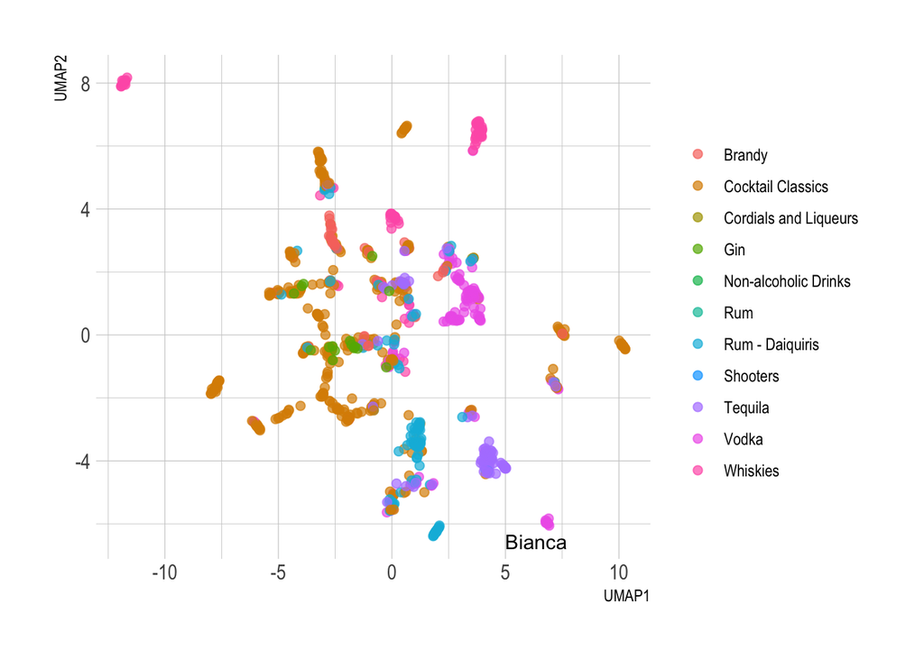

```r
juice(umap_prep) |>
  ggplot(aes(UMAP1, UMAP2, label = name)) +
  geom_point(aes(color = category), alpha = 0.7, size = 2) +
  ggrepel::geom_text_repel(check_overlap = TRUE, hjust = "inward", max.overlaps = 30) +
  labs(color = NULL) + hrbrthemes::theme_ipsum()
```

Similarly clustering seen here, but type of cocktails seen here are different.

# Conclusion

The PCA (and UMAP) using TidyModels offers a bit more customization compared to using a regular `prcomp` or `PCA-Tools`. However, it requires a bit more code and felt slightly slower in running compared to the other packages (without actually testing the time fyi)[^4].

# Additional Reading:

- Easily the best explanation of PCA on the internet: https://stats.stackexchange.com/questions/2691/making-sense-of-principal-component-analysis-eigenvectors-eigenvalues
- How PCA works - interactive plots: https://setosa.io/ev/
- How UMAP works: https://umap-learn.readthedocs.io/en/latest/how_umap_works.html
[^1]: https://bioconductor.org/packages/release/bioc/html/PCAtools.html
[^2]: https://github.com/SidhuK/R_for_Metabolomics/tree/main/Principal_Component_Analysis
[^3]: https://cmdlinetips.com/2020/06/pca-with-tidymodels-in-r/
[^4]: Plots were slower to render